# Project 2: Modeling and Evaluation - Submitted by GT User: sanne31 (sanne31@gatech.edu)

CSE6242 - Data and Visual Analytics - Summer 2018 Due: Sunday, July 24, 2018 at 11:59 PM UTC-12:00 on T-Square

```r
#removing all warning messages from the knit output
knitr::opts_chunk$set(fig.width=12, fig.height=8, fig.path='Figs/',
                      warning=FALSE, message=FALSE)
```

# Data

We will use the same dataset as Project 1: [`movies_merged`](https://s3.amazonaws.com/content.udacity-data.com/courses/gt-cs6242/project/movies_merged).

# Objective

Your goal in this project is to build a linear regression model that can predict the `Gross` revenue earned by a movie based on other variables. You may use R packages to fit and evaluate a regression model (no need to implement regression yourself). Please stick to linear regression, however.

# Instructions

You should be familiar with using an [RMarkdown](http://rmarkdown.rstudio.com) Notebook by now. Remember that you have to open it in RStudio, and you can run code chunks by pressing *Cmd+Shift+Enter*.

Please complete the tasks below and submit this R Markdown file (as **pr2.Rmd**) containing all completed code chunks and written responses, and a PDF export of it (as **pr2.pdf**) which should include the outputs and plots as well.

*Note that **Setup** and **Data Preprocessing** steps do not carry any points, however, they need to be completed as instructed in order to get meaningful results.*

# Setup

Same as Project 1, load the dataset into memory:

```r
load('movies_merged')
```

This creates an object of the same name (`movies_merged`). For convenience, you can copy it to `df` and start using it:

```r
df = movies_merged
cat("Dataset has", dim(df)[1], "rows and", dim(df)[2], "columns", end="\n", file="")
```

```
## Dataset has 40789 rows and 39 columns
```

```r
colnames(df)
```

```
##  [1] "Title"             "Year"              "Rated"
##  [4] "Released"          "Runtime"           "Genre"
##  [7] "Director"          "Writer"            "Actors"
## [10] "Plot"              "Language"          "Country"
## [13] "Awards"            "Poster"            "Metascore"
## [16] "imdbRating"        "imdbVotes"         "imdbID"
## [19] "Type"              "tomatoMeter"       "tomatoImage"
## [22] "tomatoRating"      "tomatoReviews"     "tomatoFresh"
## [25] "tomatoRotten"      "tomatoConsensus"   "tomatoUserMeter"
## [28] "tomatoUserRating"  "tomatoUserReviews" "tomatoURL"
## [31] "DVD"               "BoxOffice"         "Production"
## [34] "Website"           "Response"          "Budget"
## [37] "Domestic_Gross"    "Gross"             "Date"
```

## Load R packages

Load any R packages that you will need to use. You can come back to this chunk, edit it and re-run to load any additional packages later.

```r
#install.packages("NLP",dependencies = TRUE)
#install.packages('reshape2')
#install.packages("tm")
#install.packages("ggplot2")
#install.packages("GGally")
#install.packages("tidyr")
#install.packages("SnowballC")
#install.packages("lubridate")

library(ggplot2)
library(GGally)
library(tidyr)
library(NLP)
library(tm)
library(plyr)
library(reshape2)
library(SnowballC)
library(lubridate)
library(stringr)
```

If you are using any non-standard packages (ones that have not been discussed in class or explicitly allowed for this project), please mention them below. Include any special instructions if they cannot be installed using the regular `install.packages('<pkg name>')` command.

**Non-standard packages used**: None

# Data Preprocessing

Before we start building models, we should clean up the dataset and perform any preprocessing steps that may be necessary. Some of these steps can be copied in from your Project 1 solution. It may be helpful to print the dimensions of the resulting dataframe at each step.

## 1. Remove non-movie rows

## all prework taken from exemplary assignments pr1.rmd from Canvas

```r
# TODO: Remove all rows from df that do not correspond to movies
df <- df[df$Type == "movie", ]
dim(df)
```

```
## [1] 40000    39
```

## 2. Drop rows with missing `Gross` value

Since our goal is to model `Gross` revenue against other variables, rows that have missing `Gross` values are not useful to us.

```r
# TODO: Remove rows with missing Gross value
df <- df[!is.na(df$Gross),]
df <- df[!(df$Gross == 0),]
```

## 3. Exclude movies released prior to 2000

Inflation and other global financial factors may affect the revenue earned by movies during certain periods of time. Taking that into account is out of scope for this project, so let’s exclude all movies that were released prior to the year 2000 (you may use `Released`, `Date` or `Year` for this purpose).

```r
# TODO: Exclude movies released prior to 2000
df <- df[!(df$Year < 2000),]
```

## 4. Eliminate mismatched rows

*Note: You may compare the `Released` column (string representation of release date) with either `Year` or `Date` (numeric representation of the year) to find mismatches. The goal is to avoid removing more than 10% of the rows.*

```r
# TODO: Remove mismatched rows
rows <- df
rows$Released <- as.Date(rows$Released, "%Y-%m-%d")
rows$RelYear <- as.numeric(format(rows$Released, "%Y"))
mismatchedrows <- rows[(rows$Year == rows$RelYear),]
df <- subset(mismatchedrows, select = -RelYear)
removed_perc <- ((dim(rows)[1] - dim(df)[1])/(dim(rows)[1])) * 100
cat("Removed ",removed_perc, "% of rows")
```

```
## Removed  17.17831 % of rows
```

## 5. Drop `Domestic_Gross` column

`Domestic_Gross` is basically the amount of revenue a movie earned within the US. Understandably, it is very highly correlated with `Gross` and is in fact equal to it for movies that were not released globally. Hence, it should be removed for modeling purposes.

```r
# TODO: Exclude the `Domestic_Gross` column
df$Domestic_Gross <- NULL
```

## 6. Process `Runtime` column

```r
# TODO: Replace df$Runtime with a numeric column containing the runtime in minutes
#below code for this step taken from my own submission for project 1

raw_run_time <- df$Runtime
h_run_time <- as.numeric(gsub(".*?(\\d+) [Hh]r?.*", "\\1", raw_run_time))
h_run_time[is.na(h_run_time)] <- 0
m_run_time <- as.numeric(gsub(".*?(\\d+) [Mm]in?.*", "\\1", raw_run_time))
m_run_time[is.na(m_run_time)] <- 0

run_time <- (h_run_time * 60) + m_run_time

df$Runtime <- run_time
```

Perform any additional preprocessing steps that you find necessary, such as dealing with missing values or highly correlated columns (feel free to add more code chunks, markdown blocks and plots here as necessary).

```r
# TODO(optional): Additional preprocessing
```

**Note**: Do NOT convert categorical variables (like `Genre`) into binary columns yet. You will do that later as part of a model improvement task.

## Final preprocessed dataset

Report the dimensions of the preprocessed dataset you will be using for modeling and evaluation, and print all the final column names. (Again, `Domestic_Gross` should not be in this list!)

```r
# TODO: Print the dimensions of the final preprocessed dataset and column names
cat("Dataset has", dim(df)[1], "rows and", dim(df)[2], "columns", end="\n", file="")
```

```
## Dataset has 2536 rows and 38 columns
```

```r
colnames(df)
```

```
##  [1] "Title"             "Year"              "Rated"
##  [4] "Released"          "Runtime"           "Genre"
##  [7] "Director"          "Writer"            "Actors"
## [10] "Plot"              "Language"          "Country"
## [13] "Awards"            "Poster"            "Metascore"
## [16] "imdbRating"        "imdbVotes"         "imdbID"
## [19] "Type"              "tomatoMeter"       "tomatoImage"
## [22] "tomatoRating"      "tomatoReviews"     "tomatoFresh"
## [25] "tomatoRotten"      "tomatoConsensus"   "tomatoUserMeter"
## [28] "tomatoUserRating"  "tomatoUserReviews" "tomatoURL"
## [31] "DVD"               "BoxOffice"         "Production"
## [34] "Website"           "Response"          "Budget"
## [37] "Gross"             "Date"
```

# Evaluation Strategy

In each of the tasks described in the next section, you will build a regression model. In order to compare their performance, you will compute the training and test Root Mean Squared Error (RMSE) at different training set sizes.

First, randomly sample 10-20% of the preprocessed dataset and keep that aside as the **test set**. Do not use these rows for training! The remainder of the preprocessed dataset is your **training data**.

Now use the following evaluation procedure for each model:

- Choose a suitable sequence of training set sizes, e.g. 10%, 20%, 30%, …, 100% (10-20 different sizes should suffice). For each size, sample that many inputs from the training data, train your model, and compute the resulting training and test RMSE.
- Repeat your training and evaluation at least 10 times at each training set size, and average the RMSE results for stability.
- Generate a graph of the averaged train and test RMSE values as a function of the train set size (%), with optional error bars.

You can define a helper function that applies this procedure to a given set of features and reuse it.

# Tasks

Each of the following tasks is worth 20 points, for a total of 100 points for this project. Remember to build each model as specified, evaluate it using the strategy outlined above, and plot the training and test errors by training set size (%).

## 1. Numeric variables

Use Linear Regression to predict `Gross` based on available *numeric* variables. You can choose to include all or a subset of them.

```r
# TODO: Build & evaluate model 1 (numeric variables only)
test <- df
test$Metascore<-as.numeric(as.character(test$Metascore))
test_na<-na.omit(test)
numset_test<-sapply(test_na,is.numeric)
which_numset_test<-which(numset_test)
numset_test_vals<-test_na[,which_numset_test]

numset_test_vals<-subset(numset_test_vals,select=-tomatoRotten)
set.seed(101)
tmp_train_vals<-sample(1:nrow(numset_test_vals),size=floor(0.8*nrow(numset_test_vals)))
tmp_test_vals <- sample(1:nrow(numset_test_vals),size=floor(0.2*nrow(numset_test_vals)))
rmse_func <-function(trainingset,testingset,ratio){
  tr_rmse=c()
  te_rmse=c()
  for(i in 1:10){
    set.seed(120)
    tmp_train_vals_r<-sample(1:nrow(trainingset),size=floor(ratio*nrow(trainingset)))
    tmp_test_df<-trainingset[tmp_train_vals_r,]
    theta=lm(Gross~.,tmp_test_df)
    pdct_for_te_set = predict(theta,testingset)
    pdct_for_te_set<-as.data.frame(pdct_for_te_set)
    val_for_test=sqrt(mean((testingset$Gross - pdct_for_te_set)^2))
    tr_rmse=c(tr_rmse,sqrt(residuals(theta)^2))
    te_rmse=c(te_rmse,val_for_test)

  }
  final=c()

  final = c(final,mean(tr_rmse))
  final =c(final,mean(te_rmse))
  return (final)
}
trainer<-function(data,var_data){
sizes = c(0.1,0.15,0.2,0.25,0.3,0.35,0.4,0.45,0.5,0.55,0.6,0.65,0.7,0.75,0.8,0.85,0.9,0.95,1)
model_tr_rms = c()
model_te_rms=c()
tr_data_s<-data[var_data,]
te_data_s<-data[-var_data,]
for (val in sizes)
{
   rms_result=rmse_func(tr_data_s,te_data_s,val)
   print (rms_result)
   model_tr_rms = c(model_tr_rms,rms_result[1])
   model_te_rms=c(model_te_rms,rms_result[2])
}
rmse_model1<-data.frame(sizes,model_tr_rms,model_te_rms)
return( rmse_model1)


}
model1=trainer(numset_test_vals,tmp_train_vals)
```

```
## [1] 48081922       NA
## [1] 58774051       NA
## [1] 55431218       NA
## [1] 54516697       NA
## [1] 53768192       NA
## [1] 54000641       NA
## [1] 52990235       NA
## [1] 53052934       NA
## [1] 53557633       NA
## [1] 52569020       NA
## [1] 52668814       NA
## [1] 55334930       NA
## [1] 56700137       NA
## [1] 56598772       NA
## [1] 58549575       NA
## [1] 58913865       NA
## [1] 59030264       NA
## [1] 59771913       NA
## [1] 59745293       NA
```

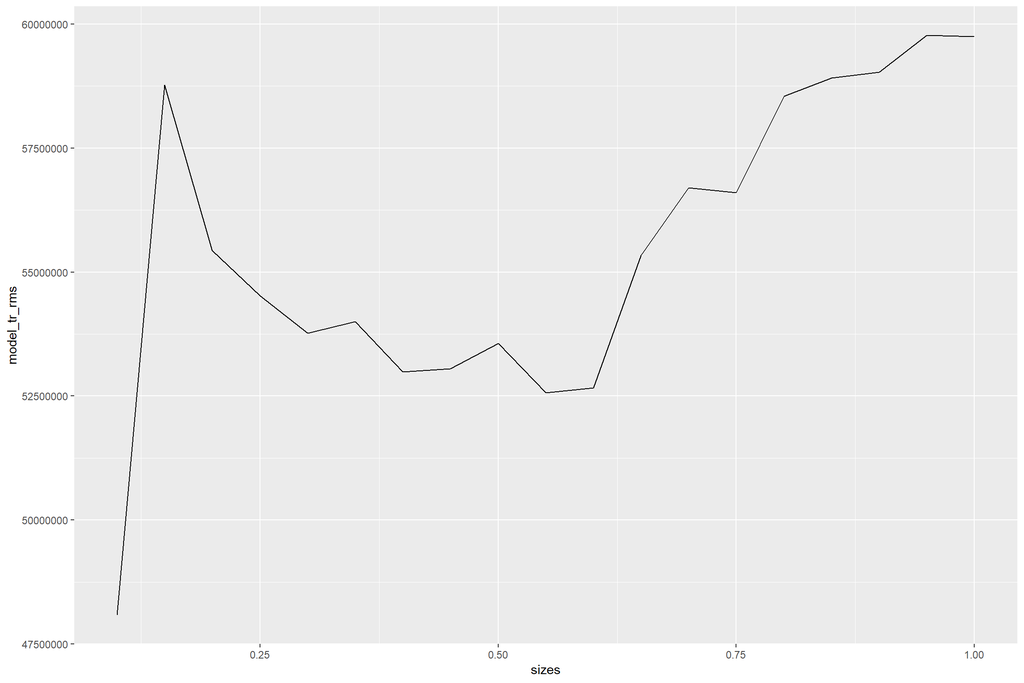

```r
ggplot(model1,aes(sizes))+geom_line(aes(y=model_tr_rms))
```

```r
model1=trainer(numset_test_vals, tmp_test_vals)
```

```
## [1] 53336524       NA
## [1] 55049640       NA
## [1] 51245212       NA
## [1] 53383563       NA
## [1] 53891243       NA
## [1] 52760091       NA
## [1] 55967885       NA
## [1] 56297702       NA
## [1] 55308730       NA
## [1] 57514109       NA
## [1] 56167748       NA
## [1] 58014831       NA
## [1] 57641860       NA
## [1] 58122619       NA
## [1] 58052874       NA
## [1] 58643637       NA
## [1] 57349394       NA
## [1] 56287292       NA
## [1] 55887728       NA
```

[figure not shown]

```r
ggplot(model1,aes(sizes))+geom_line(aes(y=model_te_rms))
```

**Q**: List the numeric variables you used.

**Q**: What is the best mean test RMSE value you observed, and at what training set size?

## 2. Feature transformations

Try to improve the prediction quality from **Task 1** as much as possible by adding feature transformations of the numeric variables. Explore both numeric transformations such as power transforms and non-numeric transformations of the numeric variables like binning (e.g. `is_budget_greater_than_3M`).

```r
# TODO: Build & evaluate model 2 (transformed numeric variables only)
numset_test_vals$t_rat_pr2<-numset_test_vals$tomatoRating^2
numset_test_vals$t_rat_pr3<-numset_test_vals$tomatoRating^3

numset_test_vals$t_fresh_pr2<-numset_test_vals$tomatoFresh^2
numset_test_vals$t_fresh_pr3<-numset_test_vals$tomatoFresh^3

numset_test_vals$t_usrev_pr2<-numset_test_vals$tomatoUserReviews^2
numset_test_vals$t_usrev_pr3<-numset_test_vals$tomatoUserReviews^3

numset_test_vals$t_usmet_pr2<-numset_test_vals$tomatoUserMeter^2
numset_test_vals$t_usmet_pr3<-numset_test_vals$tomatoUserMeter^3

numset_test_vals$t_usrat_pr2<-numset_test_vals$tomatoUserRating^2
numset_test_vals$t_usrat_pr3<-numset_test_vals$tomatoUserRating^3

numset_test_vals$t_rev_pr2<-numset_test_vals$tomatoReviews^2
numset_test_vals$t_rev_pr3<-numset_test_vals$tomatoReviews^3

numset_test_vals$t_met_pr2<-numset_test_vals$tomatoMeter^2
numset_test_vals$t_met_pr3<-numset_test_vals$tomatoMeter^3

numset_test_vals$rt_pr2<-numset_test_vals$Runtime^2
numset_test_vals$rt_pr3<-numset_test_vals$Runtime^3

numset_test_vals$ms_pr2<-numset_test_vals$Metascore^2
numset_test_vals$ms_pr3<-numset_test_vals$Metascore^3

numset_test_vals$imdb_votes_pr2<-numset_test_vals$imdbVotes^2
numset_test_vals$imdb_votes_pr3<-numset_test_vals$imdbVotes^3

transformed_runtime<-test_na$Runtime
numset_test_vals$rt_Bin<-cut(transformed_runtime,seq(min(transformed_runtime)-1,max(transformed_runtime)+1,(max(transformed_runtime) - min(transformed_runtime)+2)/6),right=FALSE,labels=c(1:6))
numset_test_vals$rt_Bin<-as.numeric(numset_test_vals$rt_Bin)

binned_imdb_rat<-numset_test_vals$imdbRating
numset_test_vals$binned_imdb_rating_val<-cut(binned_imdb_rat,seq(min(binned_imdb_rat)-1,max(binned_imdb_rat)+1,(max(binned_imdb_rat) - min(binned_imdb_rat)+2)/4),right=FALSE,labels=c(1:4))
numset_test_vals$binned_imdb_rating_val<-as.numeric(numset_test_vals$binned_imdb_rating_val)
fitted_model1 <- lm(Gross~., data = numset_test_vals)
summary(fitted_model1)
```

```
##
## Call:
## lm(formula = Gross ~ ., data = numset_test_vals)
##
## Residuals:
##        Min         1Q     Median         3Q        Max
## -410663985  -42008053   -2520356   32622190 1292246516
##
## Coefficients:
##                          Estimate Std. Error t value Pr(>|t|)
## (Intercept)            -1.185e+09  1.519e+09  -0.780  0.43542
## Year                   -2.976e+06  8.477e+06  -0.351  0.72553
## Runtime                -5.481e+06  4.414e+06  -1.242  0.21445
## Metascore               1.717e+06  3.097e+06   0.554  0.57941
## imdbRating             -1.379e+07  5.804e+06  -2.377  0.01756 *
## imdbVotes               3.843e+02  7.332e+01   5.242 1.74e-07 ***
## tomatoMeter             1.231e+06  1.572e+06   0.783  0.43344
## tomatoRating           -2.421e+07  8.520e+07  -0.284  0.77630
## tomatoReviews           1.109e+06  4.667e+05   2.376  0.01759 *
## tomatoFresh             5.228e+05  6.632e+05   0.788  0.43059
## tomatoUserMeter        -2.528e+05  3.710e+06  -0.068  0.94569
## tomatoUserRating        4.988e+08  4.784e+08   1.043  0.29715
## tomatoUserReviews       1.197e+02  1.113e+01  10.751  < 2e-16 ***
## Budget                  2.129e+00  6.664e-02  31.949  < 2e-16 ***
## Date                    3.494e+06  8.489e+06   0.412  0.68066
## t_rat_pr2               8.772e+06  1.762e+07   0.498  0.61865
## t_rat_pr3              -1.045e+06  1.134e+06  -0.922  0.35674
## t_fresh_pr2             8.190e+02  4.016e+03   0.204  0.83841
## t_fresh_pr3            -7.403e+00  8.857e+00  -0.836  0.40330
## t_usrev_pr2            -1.086e-05  9.927e-07 -10.940  < 2e-16 ***
## t_usrev_pr3             2.248e-13  2.330e-14   9.650  < 2e-16 ***
## t_usmet_pr2             3.595e+04  6.770e+04   0.531  0.59550
## t_usmet_pr3            -4.984e+02  3.959e+02  -1.259  0.20819
## t_usrat_pr2            -1.961e+08  1.483e+08  -1.323  0.18602
## t_usrat_pr3             2.794e+07  1.515e+07   1.845  0.06524 .
## t_rev_pr2              -1.313e+04  3.132e+03  -4.192 2.87e-05 ***
## t_rev_pr3               3.554e+01  7.181e+00   4.949 8.01e-07 ***
## t_met_pr2              -2.694e+04  3.029e+04  -0.889  0.37388
## t_met_pr3               2.563e+02  1.973e+02   1.299  0.19415
## rt_pr2                  3.053e+04  3.571e+04   0.855  0.39266
## rt_pr3                 -4.758e+01  9.332e+01  -0.510  0.61021
## ms_pr2                 -4.319e+04  6.577e+04  -0.657  0.51150
## ms_pr3                  3.740e+02  4.347e+02   0.860  0.38967
## imdb_votes_pr2          8.544e-05  1.518e-04   0.563  0.57355
## imdb_votes_pr3         -1.162e-10  8.016e-11  -1.449  0.14746
## rt_Bin                 -5.418e+06  7.570e+06  -0.716  0.47425
## binned_imdb_rating_val -2.179e+07  8.226e+06  -2.649  0.00813 **
## ---
## Signif. codes:  0 '***' 0.001 '**' 0.01 '*' 0.05 '.' 0.1 ' ' 1
##
## Residual standard error: 99850000 on 2207 degrees of freedom
## Multiple R-squared:  0.7541, Adjusted R-squared:  0.7501
## F-statistic:   188 on 36 and 2207 DF,  p-value: < 2.2e-16
```

```r
numset_test_vals<-subset(numset_test_vals,select=-c(t_rat_pr2,t_rat_pr3,t_fresh_pr2,t_fresh_pr3,t_usmet_pr2,t_usmet_pr3,t_usrat_pr2,t_usrat_pr3,t_met_pr2,t_met_pr3,rt_pr2,rt_pr3,ms_pr2,ms_pr3,imdb_votes_pr2,rt_Bin))
model2=trainer(numset_test_vals,tmp_train_vals)
```

```
## [1] 46225750       NA
## [1] 56094700       NA
## [1] 53445598       NA
## [1] 52376073       NA
## [1] 50694449       NA
## [1] 51531303       NA
## [1] 51193071       NA
## [1] 51055151       NA
## [1] 51556886       NA
## [1] 50545033       NA
## [1] 51340426       NA
## [1] 53338333       NA
## [1] 54630972       NA
## [1] 53997784       NA
## [1] 55986221       NA
## [1] 56075529       NA
## [1] 56317238       NA
## [1] 56946984       NA
## [1] 57185394       NA
```

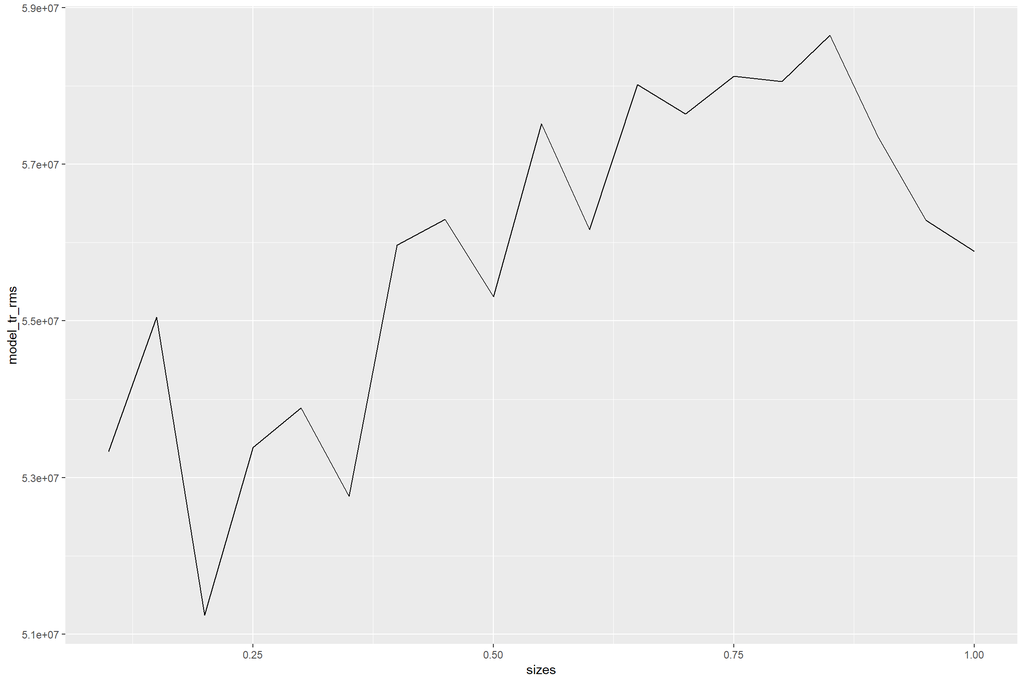

```r
ggplot(model1,aes(sizes))+geom_line(aes(y=model_tr_rms))
```

**Q**: Explain which transformations you used and why you chose them.

**A**: I chose to do some simple power transformations upon the selected numeric variables. I simply used a squared power and a cubed power transformation upon them which made trhe transformation simple and but still had some noticeable change. I also decided to bin the imdb rating values together in the thought that it might improve upon the current existing model.

**Q**: How did the RMSE change compared to Task 1?

## 3. Non-numeric variables

Write code that converts genre, actors, directors, and other categorical variables to columns that can be used for regression (e.g. binary columns as you did in Project 1). Also process variables such as awards into more useful columns (again, like you did in Project 1). Now use these converted columns only to build your next model.

```r
# TODO: Build & evaluate model 3 (converted non-numeric variables only)
#df_nagenre<-test_na
#nagenre<-df_nagenre$Genre
#applying text mining transformations to the genre column to encode it
tm_file = Corpus(VectorSource(test_na$Genre))
#removing all whitespaces from the column from each row
tm_file <- tm_map(tm_file, stripWhitespace)
#converting all values into lower case characters
tm_file <- tm_map(tm_file, tolower)
#removing any punctuation marks such as , or . etc.
tm_file <- tm_map(tm_file, removePunctuation)

#using the tm_map function to the created corpus vector
tm_map(tm_file, stemDocument, language="english")
```

```
## <<SimpleCorpus>>
## Metadata:  corpus specific: 1, document level (indexed): 0
## Content:  documents: 2244
```

```r
collection <- DocumentTermMatrix(tm_file)
tmp_genre_converted <- data.frame(as.matrix(collection))
sort(colSums(tmp_genre_converted),decreasing = T)[1:10]
```

```
##     drama    comedy    action adventure     crime   romance  thriller
##      1011       942       558       465       404       401       349
##    horror   mystery   fantasy
##       206       195       188
```

```r
top10_genre_list <- sort(colSums(tmp_genre_converted), decreasing = TRUE)
#name_list <- names(top10_genre_list)
converted_genre_vector <- tmp_genre_converted[,names(top10_genre_list)]

#to sum up the steps that i used for encoding this genre feature, I listed out the
#top 10 genres of all the movies and created a collection out of them.
#then i assigned binary values to a genre vector which had the genres listed out in order
#and had a 1 for a genre listed and matching that in the collection and vice versa

#converting the Production dataset column into an encoded feature
length(sort(table(test_na$Production), decreasing = T))
```

```
## [1] 306
```

```r
# observing only the top 15 productions
sort(table(test_na$Production), decreasing = T)[1:15]
```

```
##
##  Warner Bros. Pictures     Universal Pictures       20th Century Fox
##                    199                    188                    186
##     Paramount Pictures          Sony Pictures        New Line Cinema
##                    128                    111                     68
##   Walt Disney Pictures      Columbia Pictures Sony Pictures Classics
##                     62                     53                     49
##        Lionsgate Films           Warner Bros.         Focus Features
##                     43                     43                     42
##          Miramax Films              Lionsgate                    MGM
##                     39                     33                     32
```

```r
#Chose the top 5 variables within that dataset column
movie_prod <- data.frame(matrix(0, nrow = nrow(test_na), ncol = 5))
colnames(movie_prod) <- c("war_prod", "uni_prod", "twenty_prod", "para_prod", "sony_prod")
for(i in seq_along(test_na$Production)){
  if ( test_na$Production[i] == "Warner Bros. Pictures" ){
    movie_prod$war_prod[i] <-  1
  }else if(test_na$Production[i] == "Universal Pictures"){
    movie_prod$uni_prod[i] <- 1
  }else if(test_na$Production[i] == "20th Century Fox"){
    movie_prod$twenty_prod[i] <- 1
  }else if(test_na$Production[i] == "Paramount Pictures"){
    movie_prod$para_prod[i] <- 1
}else if(test_na$Production[i] == "Sony Pictures"){
    movie_prod$sony_prod[i] <- 1
}
}


#Transforming awards into an encoded feature
test_na$Award_Winnings = 0
test_na$Awards_Nominations = 0
Not_Award=0
for(i in 1:nrow(test_na)){
  val = as.numeric( unlist(
                         regmatches(test_na[i,'Awards'], gregexpr("+[0-9]+", test_na[i,'Awards']))))
  if(length(val)[1] == 1)
  {
      if((length(grep("win",test_na[i,]$Awards))>0) || (length(grep("won",test_na[i,]$Awards))>0)|| (length(grep("Win",test_na[i,]$Awards))>0)|| (length(grep("Won",test_na[i,]$Awards))>0)){

      test_na[i,]$Award_Winnings = as.numeric(val[1])
    }
    if(length(grep("nomination",test_na[i,]$Awards))>0){
         test_na[i,]$Awards_Nominations = as.numeric(val[1])
    }

  }
  if(length(val)[1] == 2)
  {
          if((length(grep("win",test_na[i,]$Awards))>0) || (length(grep("won",test_na[i,]$Awards))>0)|| (length(grep("Win",test_na[i,]$Awards))>0)|| (length(grep("Won",test_na[i,]$Awards))>0)){

      test_na[i,]$Award_Winnings = as.numeric(val[1])
    }
    if(length(grep("nomination",test_na[i,]$Awards))>0){

      test_na[i,]$Awards_Nominations = as.numeric(val[2])
    }

  }
  if(length(val)[1] == 3)
  {
          if((length(grep("win",test_na[i,]$Awards))>0) || (length(grep("won",test_na[i,]$Awards))>0)|| (length(grep("Win",test_na[i,]$Awards))>0)|| (length(grep("Won",test_na[i,]$Awards))>0)){

      test_na[i,]$Award_Winnings = as.numeric(val[2])
    }
    if(length(grep("nomination",test_na[i,]$Awards))>0){

      test_na[i,]$Awards_Nominations = as.numeric(val[3])
    }
  }
  if(length(val)[1] == 0){

    test_na[i,]$Award_Winnings = 0
    test_na[i,]$Awards_Nominations = 0
    Not_Award = Not_Award + 1

  }

}

base_model2 <- cbind( converted_genre_vector,movie_prod,no_of_wins=test_na$Award_Winnings,no_of_noms=test_na$Awards_Nominations,Gross=test_na$Gross)
row.names(base_model2)<-row.names(numset_test)
base_model2<-subset(base_model2,select=-c(comedy,romance,thriller,crime,mystery,family,biography,music,sport,history,documentary,war,musical,western,news,no_of_wins,para_prod))
fitted_model_1 <- lm(Gross~., data = base_model2)
summary(fitted_model_1)
```

```
##
## Call:
## lm(formula = Gross ~ ., data = base_model2)
##
## Residuals:
##        Min         1Q     Median         3Q        Max
## -555694723  -65768959  -12312668   40091138 2142924648
##
## Coefficients:
##              Estimate Std. Error t value Pr(>|t|)
## (Intercept)  36476170    6857790   5.319 1.15e-07 ***
## drama       -43813987    7580549  -5.780 8.53e-09 ***
## action       52931424    8505124   6.223 5.79e-10 ***
## adventure   132378073    9801607  13.506  < 2e-16 ***
## horror      -17870570   12027397  -1.486 0.137468
## fantasy      88468258   12356958   7.159 1.10e-12 ***
## scifi        68409047   12890199   5.307 1.22e-07 ***
## animation    88417421   15287947   5.783 8.35e-09 ***
## war_prod     53543473   11872807   4.510 6.83e-06 ***
## uni_prod     57020550   12216973   4.667 3.23e-06 ***
## twenty_prod  42179498   12341957   3.418 0.000643 ***
## sony_prod    61739198   15489469   3.986 6.94e-05 ***
## no_of_noms    2384801     120246  19.833  < 2e-16 ***
## ---
## Signif. codes:  0 '***' 0.001 '**' 0.01 '*' 0.05 '.' 0.1 ' ' 1
##
## Residual standard error: 157400000 on 2231 degrees of freedom
## Multiple R-squared:  0.3826, Adjusted R-squared:  0.3793
## F-statistic: 115.2 on 12 and 2231 DF,  p-value: < 2.2e-16
```

```r
model3=trainer(base_model2,tmp_train_vals)
```

```
## [1] 70796624       NA
## [1] 82666412       NA
## [1] 80333571       NA
## [1] 82242907       NA
## [1] 79585253       NA
## [1] 80443745       NA
## [1] 81061874       NA
## [1] 81179623       NA
## [1] 81694138       NA
## [1] 80728890       NA
## [1] 81862195       NA
## [1] 85216711       NA
## [1] 85935807       NA
## [1] 85481385       NA
## [1] 87824513       NA
## [1] 89507525       NA
## [1] 89982474       NA
## [1] 91483179       NA
## [1] 91343350       NA
```

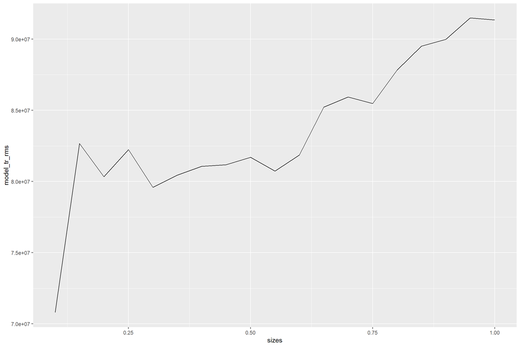

```r
ggplot(model3,aes(sizes))+geom_line(aes(y=model_tr_rms))
```

**Q**: Explain which categorical variables you used, and how you encoded them into features.

I also took the categorical variable Production. Here I took the top 15 values in that dataset to get a total of 5 production fields. I then parsed each of the row of the test dataset to create a vector for that particular variable.

Finally, observing the awards column, I decided to follow the same division methodology I used in the initial Project 1: dividing them into 2 parts awards and nominations respectively. I used the grep functionality to get the number of wins/nominations for each row and built a new vector upon that.

**Q**: What is the best mean test RMSE value you observed, and at what training set size? How does this compare with Task 2?

## 4. Numeric and categorical variables

Try to improve the prediction quality as much as possible by using both numeric and non-numeric variables from **Tasks 2 & 3**.

```r
# TODO: Build & evaluate model 4 (numeric & converted non-numeric variables)
base_model2<-subset(base_model2,select=-Gross)
base_model4 <- cbind(base_model2,numset_test_vals)
fitted_model1 <- lm(Gross~., data = base_model4)
summary(fitted_model1)
```

```
##
## Call:
## lm(formula = Gross ~ ., data = base_model4)
##
## Residuals:
##        Min         1Q     Median         3Q        Max
## -440878296  -38996489    -548634   33180498 1358687944
##
## Coefficients:
##                          Estimate Std. Error t value Pr(>|t|)
## (Intercept)            -1.750e+09  1.268e+09  -1.380 0.167799
## drama                  -3.034e+06  5.356e+06  -0.566 0.571160
## action                 -2.521e+07  5.658e+06  -4.456 8.75e-06 ***
## adventure               1.130e+07  6.687e+06   1.689 0.091280 .
## horror                  1.125e+07  7.824e+06   1.438 0.150453
## fantasy                 6.138e+06  7.995e+06   0.768 0.442706
## scifi                  -1.823e+07  8.432e+06  -2.162 0.030755 *
## animation               6.718e+07  1.078e+07   6.234 5.45e-10 ***
## war_prod               -2.050e+07  7.733e+06  -2.650 0.008095 **
## uni_prod                9.363e+06  7.860e+06   1.191 0.233698
## twenty_prod             1.260e+07  7.877e+06   1.600 0.109768
## sony_prod              -1.435e+07  9.988e+06  -1.436 0.151061
## no_of_noms             -2.664e+05  1.211e+05  -2.199 0.027952 *
## Year                   -3.604e+06  8.319e+06  -0.433 0.664890
## Runtime                -1.932e+04  1.683e+05  -0.115 0.908612
## Metascore               2.888e+05  4.290e+05   0.673 0.500857
## imdbRating             -1.655e+07  5.643e+06  -2.932 0.003398 **
## imdbVotes               4.551e+02  3.747e+01  12.144  < 2e-16 ***
## tomatoMeter             1.572e+06  4.550e+05   3.456 0.000559 ***
## tomatoRating           -2.430e+07  9.644e+06  -2.520 0.011813 *
## tomatoReviews           1.057e+06  3.198e+05   3.305 0.000964 ***
## tomatoFresh            -2.339e+05  1.772e+05  -1.320 0.186961
## tomatoUserMeter        -1.427e+06  3.934e+05  -3.626 0.000294 ***
## tomatoUserRating        1.285e+08  1.542e+07   8.334  < 2e-16 ***
## tomatoUserReviews       1.083e+02  1.100e+01   9.846  < 2e-16 ***
## Budget                  2.025e+00  7.953e-02  25.463  < 2e-16 ***
## Date                    4.389e+06  8.328e+06   0.527 0.598202
## t_usrev_pr2            -9.907e-06  9.718e-07 -10.194  < 2e-16 ***
## t_usrev_pr3             2.062e-13  2.266e-14   9.097  < 2e-16 ***
## t_rev_pr2              -1.039e+04  2.276e+03  -4.563 5.31e-06 ***
## t_rev_pr3               3.060e+01  4.881e+00   6.268 4.38e-10 ***
## imdb_votes_pr3         -7.800e-11  2.139e-11  -3.646 0.000272 ***
## binned_imdb_rating_val -2.354e+07  7.746e+06  -3.039 0.002398 **
## ---
## Signif. codes:  0 '***' 0.001 '**' 0.01 '*' 0.05 '.' 0.1 ' ' 1
##
## Residual standard error: 98770000 on 2211 degrees of freedom
## Multiple R-squared:  0.759,  Adjusted R-squared:  0.7555
## F-statistic: 217.6 on 32 and 2211 DF,  p-value: < 2.2e-16
```

```r
base_model4<-subset(base_model4,select=-c(tomatoFresh,sony_prod,uni_prod,twenty_prod,horror,fantasy,adventure,drama))
model4 = trainer(base_model4,tmp_train_vals)
```

```
## [1] 44234052       NA
## [1] 55811380       NA
## [1] 52213146       NA
## [1] 50727397       NA
## [1] 49157776       NA
## [1] 50263877       NA
## [1] 49383906       NA
## [1] 49450218       NA
## [1] 50027743       NA
## [1] 49578158       NA
## [1] 50131018       NA
## [1] 52900358       NA
## [1] 54502169       NA
## [1] 53740652       NA
## [1] 55524621       NA
## [1] 55447079       NA
## [1] 55625273       NA
## [1] 56155163       NA
## [1] 56147772       NA
```

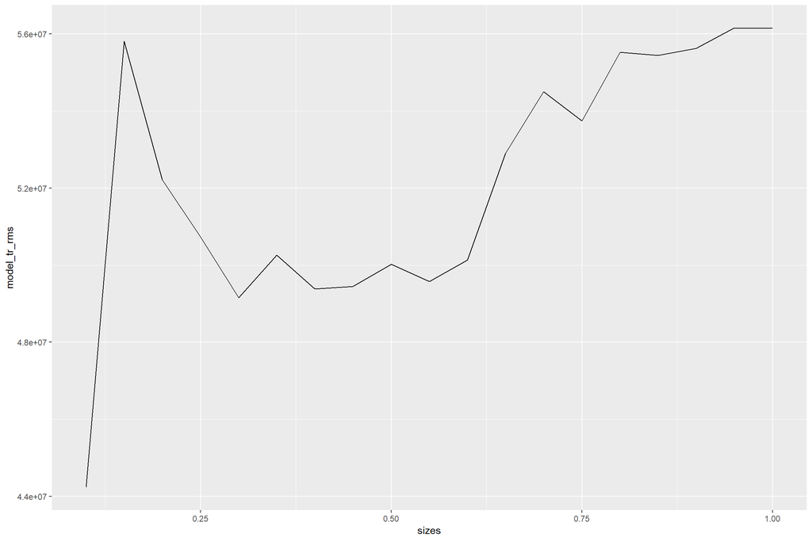

```r
ggplot(model4,aes(sizes))+geom_line(aes(y=model_tr_rms))
```

**Q**: Compare the observed RMSE with Tasks 2 & 3.

**A**: The RMSE values observed for model4 seem to be similar in range to those RMSE values of model2. The model3 values are much higher than both of these values for both the models and model4 seems to have produced the least RMSE values of all the analyses done above.

## 5. Additional features

Now try creating additional features such as interactions (e.g. `is_genre_comedy` x `is_budget_greater_than_3M`) or deeper analysis of complex variables (e.g. text analysis of full-text columns like `Plot`).

```r
# TODO: Build & evaluate model 5 (numeric, non-numeric and additional features)
cat = 1:5
num = 6:24
new_feat <- data.frame(matrix(0, nrow = dim(base_model4)[1], ncol= 0))
new_feat_colnames<-c()
for (i in num){
  for (j in cat){
     tmp <- paste("relate", colnames(base_model4)[i], colnames(base_model4)[j], sep = "_")
    new_feat_colnames <- c(new_feat_colnames, tmp)
    cols = base_model4[i] * base_model4[j]
    new_feat <- cbind(new_feat, cols)
  }
}
colnames(new_feat) <- new_feat_colnames
new_df <- cbind(base_model4, new_feat)
fitted_model5 <- lm(Gross~., data = new_df)
base_model5 <- new_df[, (summary(fitted_model5)$coefficients[, 4] < 0.05)]

model5 = trainer(base_model5,tmp_train_vals)
```

```
## [1] 21600434       NA
## [1] 25736258       NA
## [1] 25974866       NA
## [1] 26005287       NA
## [1] 26480921       NA
## [1] 27100867       NA
## [1] 26676806       NA
## [1] 26460904       NA
## [1] 27723847       NA
## [1] 28261057       NA
## [1] 28192837       NA
## [1] 28583561       NA
## [1] 28650093       NA
## [1] 28598801       NA
## [1] 28593887       NA
## [1] 28997029       NA
## [1] 29078845       NA
## [1] 29466045       NA
## [1] 29596824       NA
```

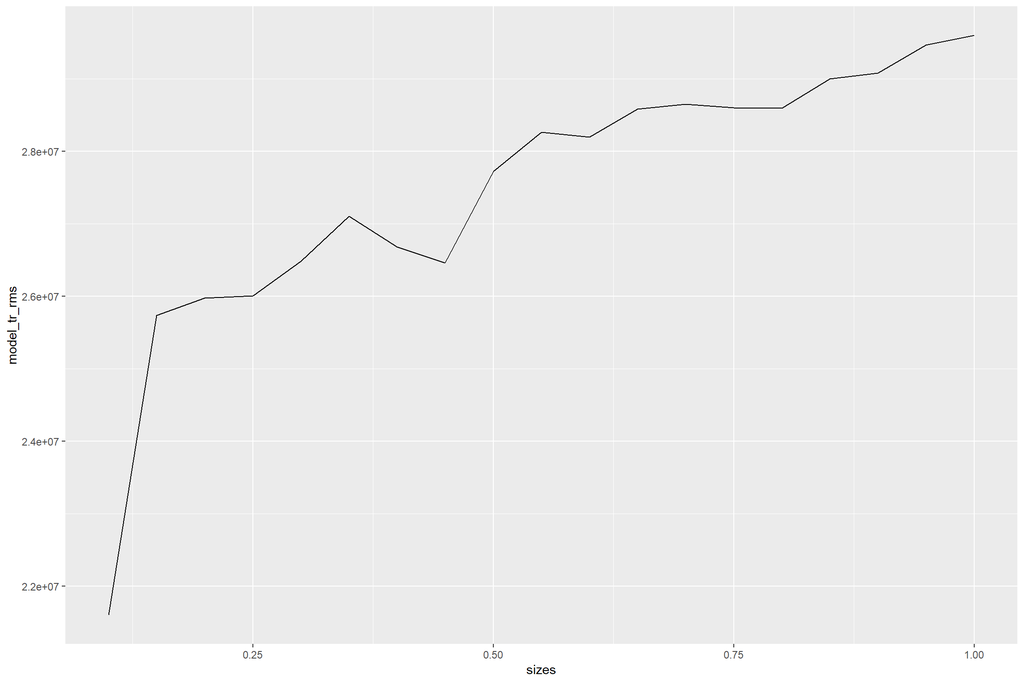

```r
ggplot(model5,aes(sizes))+geom_line(aes(y=model_tr_rms))
```

**Q**: Explain what new features you designed and why you chose them.

**A**: I chose to just create a simple relation between the categorical variables and the numerical variables because the majority of the dataset is based upon the relation between them and how they affect training models.

**Q**: Comment on the final RMSE values you obtained, and what you learned through the course of this project.

**A**: The final RMSE value I obtained was 29596824 at a training set size of 100%. One of the key things I learnt from this project was that the selection of features in a model is crucial to whatever future steps might be taken to either process it or train another model based upon it. Choosing the right features improves prediction drastically and we can see that change above in all of the five models described above. Below we can see the difference in the RMSE values for all the trained models.

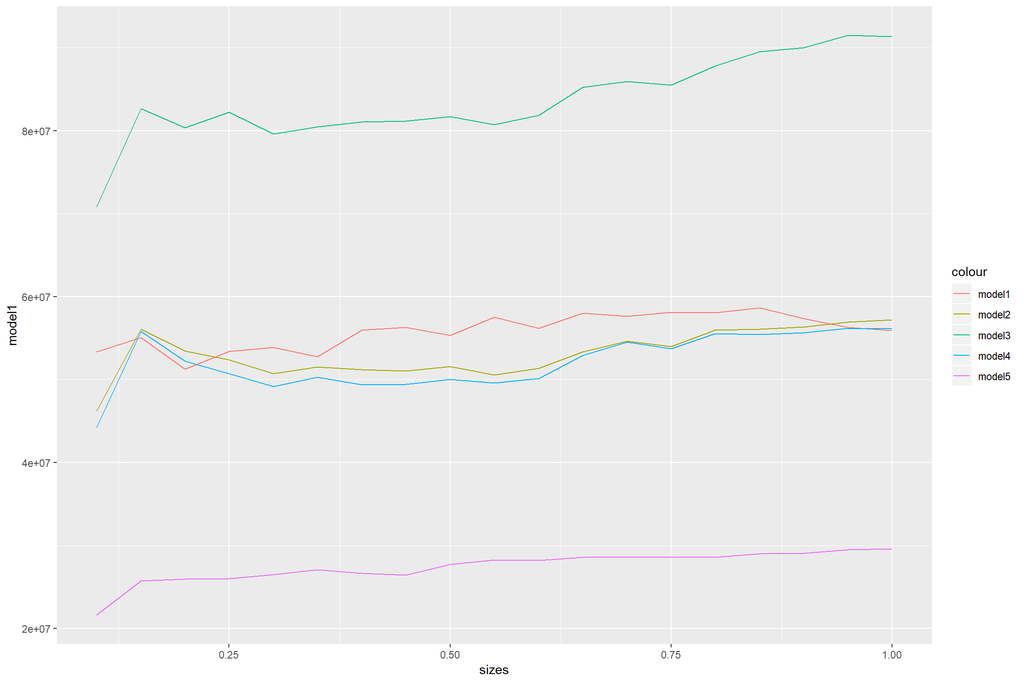

```r
allModels<-merge(model1,model2,by="sizes")
allModels<-merge(allModels,model3,by="sizes")
allModels<-merge(allModels,model4,by="sizes")
allModels<-merge(allModels,model5,by="sizes")

colnames(allModels)<-c("sizes","model1","model1_test","model2","model2_test","model3","model3_test","model4","model4_test","model5","model5_test")
allModels$model1_test <- NULL
allModels$model2_test <- NULL
allModels$model3_test <- NULL
allModels$model4_test <- NULL
allModels$model5_test <- NULL

ggplot(allModels, aes(sizes)) + geom_line(aes(y = model1, color = "model1"))+
  geom_line(aes(y = model2, color = "model2")) +
  geom_line(aes(y = model3, color = "model3")) +
  geom_line(aes(y = model4, color = "model4")) +
  geom_line(aes(y = model5, color = "model5"))
```

# References:

https://stackoverflow.com/questions/32523544/how-to-remove-error-in-term-document-matrix-in-r http://stat.ethz.ch/R-manual/R-devel/library/stats/html/lm.html https://www.rdocumentation.org/packages/base/versions/3.5.1/topics/seq http://kbroman.org/knitr_knutshell/pages/Rmarkdown.html